# Convolution & sum of RVs

### **NOTES ON STATISTICS, PROBABILITY and MATHEMATICS**

### Convolution to find CDF $Z = X + Y$:

We are given the joint pdf. For instance in the case of the uniform distribution:

$$f_{XY}(x,y)= \mathbb 1_{(0,a)}\times
\mathbb 1_{(0,b)}$$

and we want to find the pdf of $f_Z(z)$ where $Z=X+Y$.

We start with the distribution (cdf) function:

$$F_Z(z) = \Pr(Z \leq z) = \Pr(x+y \leq
z)$$

to later obtain the pdf through the derivative.

This is what would go on integrating under the bivariate uniform:

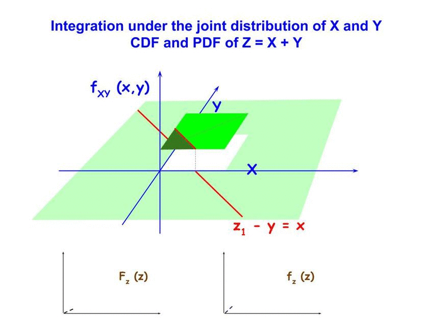

In general, we would have to integrate as follows:

$$\begin{align}
\color{orange}{F(z)} &= \Pr(Z \leq z)\\ &= \Pr(x + y \leq z) =
\displaystyle \int_{-\infty}^{\infty}
\color{orange}{\int_{-\infty}^{z-y} f_{XY} (x,y)\, d x} \, dy
\end{align}$$

To take the derivative on both sides of the equation we have to use Leibniz rule because $z$ is in the limits of integration of the expression in orange. In trying to get the derivative of a function like that we do:

$$\frac{d}{dx}\left(\displaystyle
\int_\color{red}{{b(x)}}^\color{red}{{a(x)}} f(x,t) \, dt \right)
=\displaystyle \int_\color{red}{{b(x)}}^\color{red}{{a(x)}}\,
\frac{\partial f(x,t)}{\partial x}\,dt + \color{blue}{f(a(x), x)} \,
\color{red}{a'(x)} - \color{blue}{f(b(x), x)} \color{red}{ \,
b'(x)}\tag {*}$$

In what follows, though, we have not just $x$ and $t$, but rather $z$, $y$ and $x$, which makes it a bit confusing. We are differentiating with respect to $z$ ($z$ being the “new player” not in the two-variable equation (*)); the new $x$ will play the role of the old $t$, while $y$ will play the role of the old $x$:

$$\begin{align}
f_Z(z) =& \frac{dF_z (z)}{dz}\\[2ex]
=& \displaystyle \int_{-\infty}^{\infty} \left[
\color{orange}{\frac{d}{dz} \int_{-\infty}^{z-y} f_{XY}(x,y)\,dx}
\right]\,dy \\[2ex]
=& \displaystyle \int_{-\infty}^{\infty} \left[ \int_{-\infty}^{z-y}
\frac{\partial f_{XY}(x,y)}{\partial z}dx + \color{blue}{\,
f_{XY}(z-y,\, y)} \, \color{red}{\frac{d(z-y)}{dz}} -
\color{blue}{f_{XY}(b(y),y)}
\color{red}{\frac{d(-\infty)}{dz}} \right] dy\\[2ex]
=&\int_{-\infty}^{\infty} \left[ \int_{-\infty}^{z-y} \frac{\partial
f_{XY}(x,y)}{\partial z}dx + \color{blue}{\, f_{XY}(z-y,\, y)} \,
\color{red}{1} - \color{red}{0} \right] dy\tag 1\\[2ex]
=& \int_{-\infty}^{\infty} \color{blue}{\, f_{XY}(z-y,\, y)} \,
dy \tag 2\\[2ex]
=&\int_{-\infty}^{\infty} \, f_{X}(z-y) \, f_{Y}(y) \,dy \tag 3
\end{align}$$

Notice that $-\infty$ is a constant (yielding eq 1); therefore, the derivative with respect to $z$, or anything else, will be $0$. Also $\frac{\partial f_{XY}(x,y)}{\partial z}$ is zero (yielding eq 2). $X$ and $Y$ are independent, justifying eq. 3, which is the convolution $f_X(z)*f_Y(z)$.

Especial case: the uniform distribution:

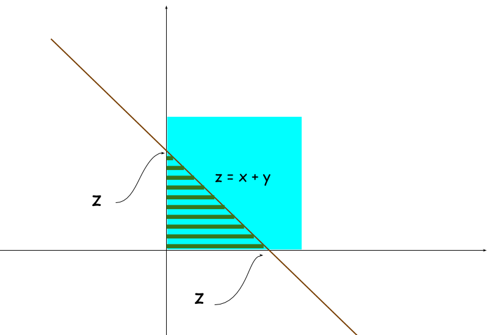

Hence,

$$\begin{align}
f_Z(z)&=\displaystyle\int_0^z f_{X}(z-y)f_{Y}(y)\,dy\\[2ex]
&=\displaystyle\int_0^z \mathbb 1_{\{(z-y)\in [0,1]\}}\;\mathbb
1_{\{(y\in [0,1]\}}\,dy\\[2ex]
&=\int_0^z \mathbb 1_{\{(z-y)\in [0,1]\}}\,dy\tag 4
\end{align}$$

Since $f_Y(y)=1$ if $0\leq y\leq 1$ and $0$ otherwise, we get eq. 4.

Since $z = x+y$, it can reach $2$. If $0\leq z \leq 1$,

$$f_Z(z)=\displaystyle \int_0^z dy =
z$$

whereas if $1 \leq z \leq 2$, and given that we are integrating over $y$, and the integrand is $1$ only when $0\leq z-y \leq 1$ (rearranged: $z-1 \leq y \leq z$):

$$f_Z(z)=\int_{z-1}^{1} dy =
2-z.$$

Problem from [SE](https://math.stackexchange.com/a/2611145/152225):

> Calculate $\Pr\left(x_1 + x_2 < 1 \, \vert \, x_1 < \frac{1}{7}\right)$ with $X_1$ and $X_2$ corresponding to iid standard uniform distributions.

By the definition of conditional probability:

$$\Pr\left(x_1 + x_2 < 1 \, \vert \,
x_1 < \frac{1}{7}\right) = \frac{\Pr\left(x_1 + x_2 < 1 \;\cap\;
x_1 < \frac{1}{7}\right)}{\Pr\left(x_1 <
\frac{1}{7}\right)}.$$

The denominator is $\Pr\left(x_1 < \frac{1}{7}\right)=\frac{1}{7}.$

As for the numerator: Since $X_1$ and $X_2$ are independent and $U(0,1)$, it corresponds to the area of the region

$$\Bigg\{(x,y) \in [0,1]\times[0,1] : x +
y < 1\;,\; x < \frac{1}{7}\Bigg\}.$$

Here is the area to calculate for the numerator (in dashed purple lines):

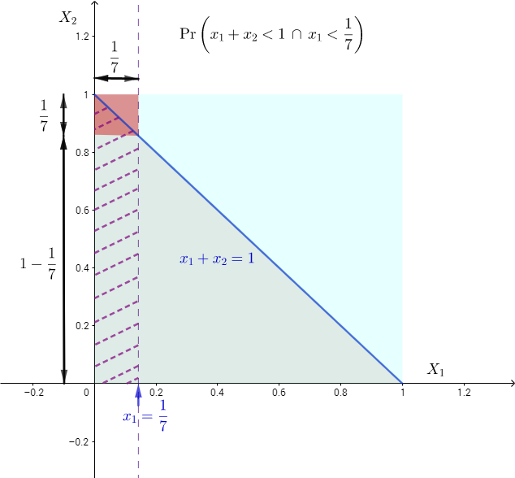

We can calculate it as the area of the vertical rectangle under the purple dashed lines, and excluding the red square

$$\text{base} \times \text{height}
=\frac{1}{7}\left(1- \frac{1}{7}\right)$$

plus the 1/2 of the red square:

$$\frac{1}{2}(\text{side})^2=\frac{1}{2}\left(\frac{1}{7}\right)^2$$

Hence,

$$\Pr\left(x_1 + x_2 < 1 \,\cap\, x_1
< \frac{1}{7} \right)=\frac{1}{7}\left(1-
\frac{1}{7}\right)+\frac{1}{2}\left(\frac{1}{7}\right)^2=\frac{13}{98}.$$

Integrating instead,

$$\int_0^{1/7} \int_0^{1 - x} dy\,dx =
\int_0^{1/7} (1 - x)\,dx = \frac{13}{98}.$$

Dividing this by the denominator $1/7,$

$$\Pr\left(x_1 + x_2 < 1 \, \vert \,
x_1 < \frac{1}{7}\right) = \frac{13}{14}\,.$$

[Home Page](http://rinterested.github.io/statistics/index.html)

**NOTE: These are tentative notes on different topics for personal use - expect mistakes and misunderstandings.**